# Evaluating SDM performance

2015-09-10

## a note on using this presentation

- press 'p' to see a note with a brief explanation for each slide
- press 'f' to see the presentation in 'full screen' mode

## Model validation is a big issue

### points covered here:

- what is validation?
- the purpose of SDMs
- criteria for SDM adequacy
- current 'SDM-validation' practices
- suggestions for improvement

## What is validation?

- perhaps not a good term, better: evaluation ([Oreskes, 1998](http://www.jstor.org/stable/4641214))
- Three imporant questions ([Beck,2002](http://www.nusap.net/downloads/articles/Beck2001.pdf)):
  - were approved materials & methods used for model construction?
  - does it approximate the 'real thing' well?
  - does it serve its intended purpose?

## right materials & methods?

### Data

```
- predictor variables
    - quality
    - resolution
    - realism
- occurrence/abundance data
    - quality
    - size
```

### Method

```
- appropriate/balanced workflow
   - model-type/algorithm
   - training/testing cycle
   - error-metrics
- quality checks/reproducibility
```

## the purpose of SDMs

- **predict** where a species occurs
- **suggest** why a species does(n't) occur somewhere

### Other reasons to construct a model (f.i.):

- encode contemporary knowledge about a system unambiguously
- provide exploratory tool to generate ideas and make ignorance explicit
- communicate scientific notions to a non-expert audience

## when does an SDM achieve its purpose?

### How to measure predictive performance?

```
- choice of index/indices
- splitting data for training & testing (evaluating)
- avoiding artifacts & comparing across studies
```

### How to learn from a model?

```
- interpreting differences among models
- deal with scale-effects
- avoid over-interpretation of statistical relations
```

## When does an SDM predict well?

- high score for performance index on **unseen** data
  - AUC, TSS (or any other index based on conf.matrix)
  - **metrics of spatial overlap** (e.g. Schoener's index)
- consistency in response functions for different data

### important issues:

- absolute scores of indices often case-dependent
  - comparison to null model is important
  - conflicting results among studies (for unknown reasons)
- sensitivity of outcome to arbitrary or undocumented model choices

## A note about performance indices

### Who has a favourite?

- Which one(s)?

### Arguments in favour of/against using an index?

- has been used previously in similar studies
- can be calculated, given the constraints
- has desirable properties (which properties?)

## the ideal index doesn't exist (sorry)

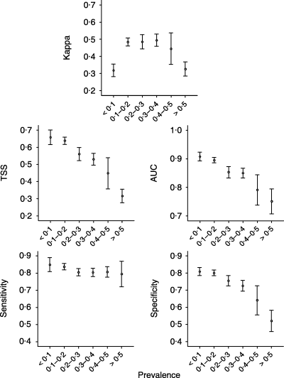

## Why is data splitting needed at all?

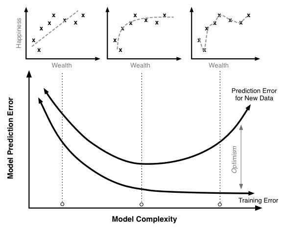

## Different ways to split

### single data source/survey

- split once
- cross-validation random/unstratified
- cross-validation stratified
- different part of spatio/temporal domain

## Different ways to split

### different data sources/surveys

- split once
- cross-over designs (train on one, evaluate on others)
- etc.

## Model evaluation with various data sources

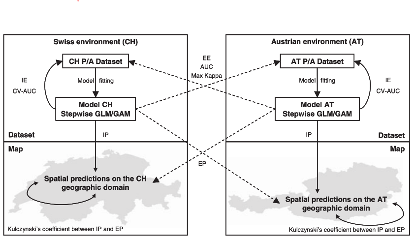

## Synthetic data in model validation

- correct model
- incorrect model
- different levels of noise (e.g. random predictors)
- etc.

## Fresh ideas

- make evaluation spatially explicit
- explore relation between predictor resolution, model resolution and predictive performance
- apply the concepts of 'behavioural models' & equifinality

## Think spatially

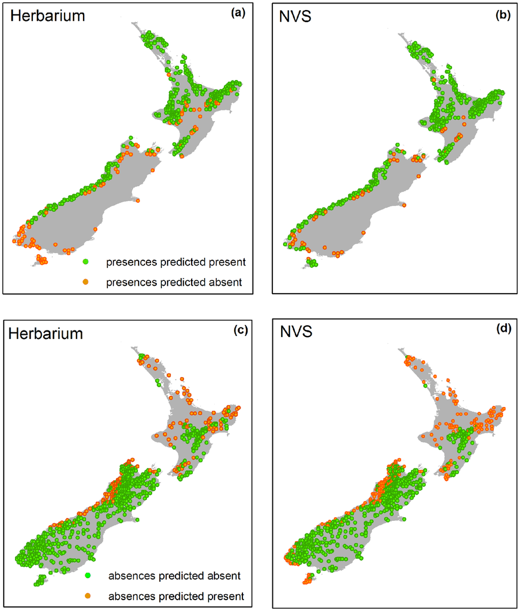

## And the role of ZOÖN?

- (e.g.) implement the functions for cross-validation in ENMeval [Muscarella et al (2014)](http://dx.doi.org/10.1111/2041-210X.12261)
- design, test & share your own ideal model evaluation workflow